[GitHub](https://github.com/Janssena/DeepCompartmentModels.jl)[](https://github.com/Janssena/DeepCompartmentModels.jl/blob/main/tutorials/01-basic-dcm.qmd)

# A first Deep Compartment Model

*Fitting a one-compartment model with a neural network to theophylline data*

A *deep compartment model* (DCM) keeps the structure of a classical pharmacokinetic model, a system of ODEs describing how a drug moves through the body, but lets a neural network predict the ODE parameters (clearance, volume, ...) from patient covariates. This tutorial walks through the whole loop on a small, classical dataset:

1. build `Individual`s and a `Population` from a table,
2. define the neural network and the model,
3. fit it by minimising the sum of squared errors,
4. look at the predictions.

The data are the theophylline dataset: 12 subjects who each got a single oral dose and were sampled over 24 hours. The only covariate is body weight.

## Setup

```julia
using DeepCompartmentModels   # also re-exports Lux, Optimisers, OrdinaryDiffEq, ...
using DataFrames, CSV
using CairoMakie
using Random
```

## Data

```julia
df = DataFrame(CSV.File(joinpath(pkgdir(DeepCompartmentModels), "data", "theophylline.csv")))
first(df, 4)
```

4×5 DataFrame

| Row | ID Int64 | AMT Float64 | TIME Float64 | DV Float64? | WEIGHT Float64 |
| --- | --- | --- | --- | --- | --- |
| 1 | 1 | 4.02 | 0.0 | missing | 79.6 |
| 2 | 1 | 4.02 | 0.25 | 2.84 | 79.6 |
| 3 | 1 | 4.02 | 0.57 | 6.57 | 79.6 |
| 4 | 1 | 4.02 | 1.12 | 10.5 | 79.6 |

Each subject has one dosing row (`DV` is `missing`) and a series of concentration measurements. `AMT` is the dose in mg/kg, so the dose in mg is `AMT * WEIGHT`.

An `Individual` bundles the covariates `x`, the observation times `t`, the observations `y` and a *dosing callback* that tells the ODE solver when and how much drug enters the system. `generate_dosing_callback` builds that callback from a matrix with one row per dose, `[time amount]`:

```julia
function make_individual(g)
    obs = g[.!ismissing.(g.DV), :]
    dose = g.AMT[1] * g.WEIGHT[1]                      # mg
    callback = generate_dosing_callback([0.0 dose])    # a bolus at t = 0
    return Individual(g.ID[1], [g.WEIGHT[1]], obs.TIME, obs.DV, callback)
end

population = Population([make_individual(g) for g in groupby(df, :ID)])
length(population), population[1]
```

```
(12, BasicIndividual{Float32}(id = 1, ...))
```

Everything is stored as `Float32` by default. A `Population` behaves like a vector of individuals, so it can be indexed and sliced; `get_t`, `get_y` and `get_x` pull out the times, observations and covariates.

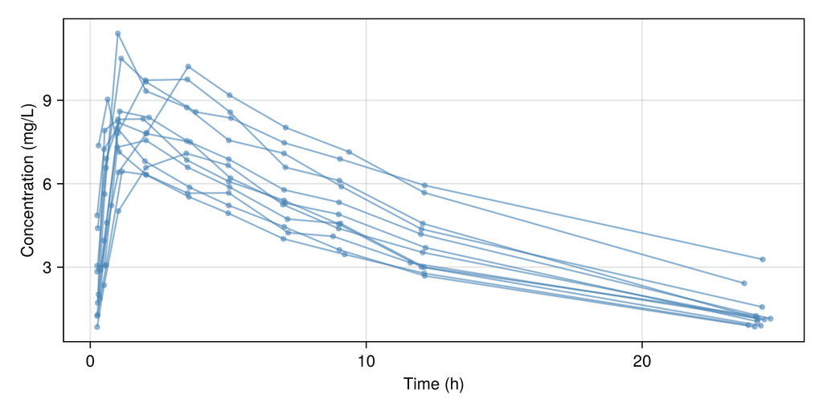

```julia
fig = Figure(size = (700, 350))
ax = Axis(fig[1, 1]; xlabel = "Time (h)", ylabel = "Concentration (mg/L)")
for indv in population
    scatterlines!(ax, get_t(indv), get_y(indv); color = (:steelblue, 0.6), markersize = 7)
end
fig
```

## The model

Theophylline is absorbed from the gut and eliminated from the central compartment, so we use `one_comp_abs!`, a built-in ODE with a depot and a central compartment. Its parameters are `[kₐ, CL, V]`: the absorption rate, the clearance and the volume of distribution. The package ships `one_comp!`, `one_comp_abs!`, `two_comp!` and `two_comp_abs!`; the custom ODE tutorial shows how to write your own.

The network maps the (normalised) weight to those three positive parameters:

```julia
ann = Lux.Chain(
    Normalize([100f0]),                  # min-max scale weight with an upper bound of 100 kg
    Lux.Dense(1, 8, tanh),
    Lux.Dense(8, 3, Lux.softplus),       # kₐ, CL and V must be positive
    Lux.WrappedFunction(x -> x .* Float32[1, 3, 30]),  # start near plausible magnitudes
)
```

```
Chain(
    layer_1 = Normalize(lower = Float32[0.0], upper = Float32[100.0]),
    layer_2 = Dense(1 => 8, tanh),                # 16 parameters
    layer_3 = Dense(8 => 3, softplus),            # 27 parameters
    layer_4 = WrappedFunction(#5),
)         # Total: 43 parameters,
          #        plus 2 states.
```

The last layer rescales the outputs so that training starts at physiologically plausible values (a volume of about 30 L rather than 1 L). This is a modelling choice, not a requirement.

```julia
problem = ODEProblem(one_comp_abs!, zeros(Float32, 2), (-0.1f0, 1f0); dt = 0.01f0)
model = DCM(problem, ann; target = 2)
```

```
DeepCompartmentModel{ode = one_comp_abs!, error = ImplicitError}
```

The time span of the problem is a placeholder: it is replaced by the span of each individual when solving. Its *start* matters, though. It has to lie before the first dose, because the dosing callback only fires at times the solver steps to after starting. Hence `-0.1`, which is also what `DCM(ode_fn, ...)` uses.

`target = 2` selects which ODE state is compared to the observations. In `one_comp_abs!` state 1 is the *amount* in the depot and state 2 the *concentration* in the central compartment, which is what was measured. (The default is `target = 1`.)

Tip

`DCM(one_comp_abs!, ann)` builds the `ODEProblem` for you. Creating it explicitly, as here, lets you pass solver defaults along: the `dt = 0.01f0` is the solver's *initial* step size. Every individual starts with an empty body, and the solver's automatic choice of a first step then logs a "dt_epsilon" warning on each of the thousands of solves in a fit. The initial `dt` is only a starting point, the step size is still adaptive. The same keyword (and `reltol`, `abstol`, `solver`, ...) can also be passed to `predict`.

## Fitting

`setup` initialises the parameters `ps` (what is learned) and the state `st` (constants of the model) for a given objective. `SSE()` is the sum of squared errors:

```julia
rng = Random.Xoshiro(1)
objective = SSE()
ps, st = setup(objective, rng, model)
objective(model, population, ps, st)
```

```
802.0404f0
```

Objectives are plain callables, `objective(model, data, ps, st)`. `gradient` returns the gradient of the objective with respect to `ps`, with the same structure as `ps`, so it plugs straight into Optimisers.jl:

```julia
function train(objective, model, population, ps, st; epochs, lr)
    opt_state = Optimisers.setup(Optimisers.Adam(lr), ps)
    losses = Float32[]
    for _ in 1:epochs
        ∇ = gradient(objective, model, population, ps, st)
        opt_state, ps = Optimisers.update(opt_state, ps, ∇)
        push!(losses, objective(model, population, ps, st))
    end
    return ps, losses
end

ps, losses = train(objective, model, population, ps, st; epochs = 150, lr = 0.02f0)
losses[[1, 50, 100, 150]]
```

```
4-element Vector{Float32}:
 617.7432
 243.60455
 235.09656
 231.07932
```

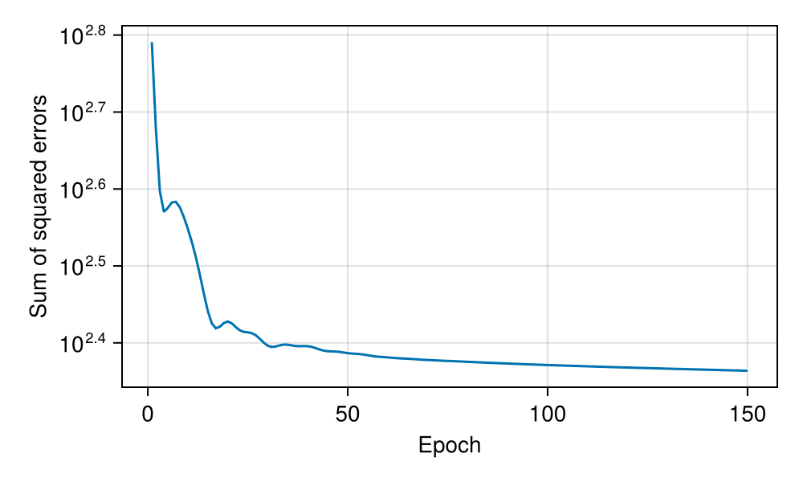

```julia
fig = Figure(size = (500, 300))
ax = Axis(fig[1, 1]; xlabel = "Epoch", ylabel = "Sum of squared errors", yscale = log10)
lines!(ax, losses)
fig
```

## Predictions

`predict(model, data, ps, st)` solves the ODE for every individual and returns the predicted observations at the observed times. Pass `saveat` for a dense grid:

```julia
ŷ = predict(model, population, ps, st)
ŷ[1]
```

```
10-element Vector{Float32}:
 3.1317222
 5.6455297
 7.565111
 8.088767
 7.1614814
 6.393692
 5.3728857
 4.4771605
 3.3932586
 1.1226623
```

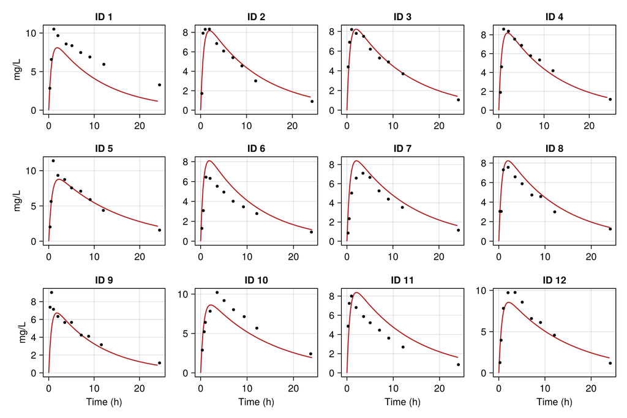

```julia
grid = 0:0.25:24
fig = Figure(size = (900, 600))
for (i, indv) in enumerate(population)
    local ax = Axis(fig[fld(i - 1, 4) + 1, mod1(i, 4)]; title = "ID $(indv.id)",
              xlabel = i > 8 ? "Time (h)" : "", ylabel = mod1(i, 4) == 1 ? "mg/L" : "")
    lines!(ax, grid, predict(model, indv, ps, st; saveat = grid); color = :firebrick)
    scatter!(ax, get_t(indv), get_y(indv); color = :black, markersize = 6)
end
fig
```

The network has learned a weight-dependent set of parameters. `predict_typ_parameters` returns them for any set of individuals, one column per individual:

```julia
ζ, _ = predict_typ_parameters(model, population, ps, st)
DataFrame(permutedims(ζ), ["ka (1/h)", "CL (L/h)", "V (L)"])
```

12×3 DataFrame

| Row | ka (1/h) Float32 | CL (L/h) Float32 | V (L) Float32 |
| --- | --- | --- | --- |
| 1 | 1.66205 | 3.01642 | 33.407 |
| 2 | 1.60698 | 2.78956 | 33.101 |
| 3 | 1.59132 | 2.72422 | 32.9889 |
| 4 | 1.60941 | 2.79968 | 33.1174 |
| 5 | 1.44586 | 2.11723 | 31.3644 |
| 6 | 1.66491 | 3.028 | 33.4193 |
| 7 | 1.53999 | 2.50904 | 32.5388 |
| 8 | 1.59132 | 2.72422 | 32.9889 |
| 9 | 1.7076 | 3.19826 | 33.5635 |
| 10 | 1.48052 | 2.26039 | 31.8512 |
| 11 | 1.54359 | 2.52414 | 32.5746 |
| 12 | 1.50227 | 2.351 | 32.1239 |

Note

With only 12 subjects and one covariate this is a demonstration of the mechanics, not a serious model: there is no way to tell here whether the weight effect is real. The next tutorials add inter-individual variability and a likelihood.

## Next

- Loading data: getting your own data into `Individual`s, with multiple doses, infusions and units.
- Mixed effects: random effects and the variational ELBO.